# Assignment03

Erik Fichter

9/19/2020

```r
library(tidyverse)
```

```r
library(ggplot2)
```

## Analysis for correlation between residential buildings (value, type, size etc) and commute time to work

```r
ma_re_trans_data<- read.csv("2018 RE Transportation.csv")
ma_re_trans_data
```

# Correlation between two continuous variables - Pearson’s correlation

## Property Value (Con) and Traveltime (Con)

While the correlation between property value and traveltime is weak, it is statistically significant.

```r
correlation <- cor.test(ma_re_trans_data$VALP, ma_re_trans_data$JWMNP)

correlation
```

```
##
##  Pearson's product-moment correlation
##
## data:  ma_re_trans_data$VALP and ma_re_trans_data$JWMNP
## t = 6.1236, df = 23000, p-value = 9.297e-10
## alternative hypothesis: true correlation is not equal to 0
## 95 percent confidence interval:
##  0.02743599 0.05324029
## sample estimates:
##        cor
## 0.04034487
```

As seen in the figure, this positive correlation means that as value increases, traveltime grows.

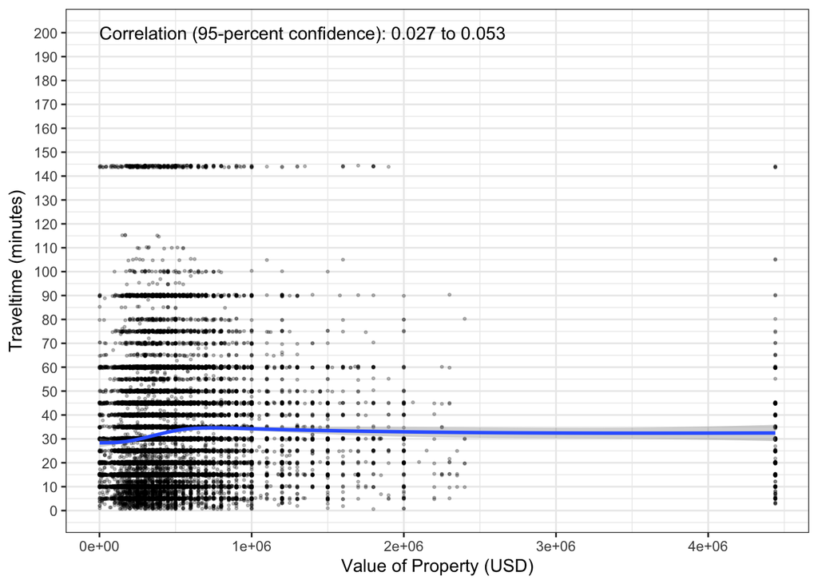

```r
ggplot(ma_re_trans_data, aes(x = VALP, y = JWMNP)) +
  geom_point(size = 0.5, alpha = 0.25, position = "jitter") +
  geom_smooth() +
  theme_bw() +
  scale_x_continuous(name = "Value of Property (USD)") +
  scale_y_continuous(name = "Traveltime (minutes)",
                     breaks = seq(0, 6000, by = 10),
                     labels = paste("",
                      prettyNum(seq(0, 6000, by = 10),
                      big.mark = ","))) +
  annotate(geom = "text", x = 0, y = 200,
           label = paste("Correlation (95-percent confidence):",
                         prettyNum(correlation$conf.int[1], digits = 2),
                         "to",
                         prettyNum(correlation$conf.int[2], digits = 2)),
           hjust = 0)
```

## Nuber of Bedrooms (Con) and Traveltime (Con)

While the correlation between bedrooms and traveltime is weak, it is statistically significant.

```r
correlation2 <- cor.test(ma_re_trans_data$BDSP, ma_re_trans_data$JWMNP)

correlation2
```

```
##
##  Pearson's product-moment correlation
##
## data:  ma_re_trans_data$BDSP and ma_re_trans_data$JWMNP
## t = 3.4731, df = 23000, p-value = 0.0005155
## alternative hypothesis: true correlation is not equal to 0
## 95 percent confidence interval:
##  0.009974548 0.035807365
## sample estimates:
##        cor
## 0.02289478
```

As seen in the figure, this very small but positive correlation means that as the number of bedrooms increase, traveltime grows. A reason for that might be that bigger homes are further away from the CBD and office hubs as they are more affordable in the outskirts.

[figure not shown]

```r
ggplot(ma_re_trans_data, aes(x = BDSP, y = JWMNP)) +
  geom_point(size = 0.5, alpha = 0.25, position = "jitter") +
  geom_smooth() +
  theme_bw() +
  scale_x_continuous(name = "Number of Bedrooms") +
  scale_y_continuous(name = "GTraveltime (minutes)",
                     breaks = seq(0, 6000, by = 10),
                     labels = paste("",
                      prettyNum(seq(0, 6000, by = 10),
                      big.mark = ","))) +
  annotate(geom = "text", x = 0, y = 200,
           label = paste("Correlation (95-percent confidence):",
                         prettyNum(correlation$conf.int[1], digits = 2),
                         "to",
                         prettyNum(correlation$conf.int[2], digits = 2)),
           hjust = 0)
```

# Gross Monthly Rent (Con) and Traveltime (Con)

```r
correlation <- cor.test(ma_re_trans_data$GRNTP, ma_re_trans_data$JWMNP)
correlation
```

```
##
##  Pearson's product-moment correlation
##
## data:  ma_re_trans_data$GRNTP and ma_re_trans_data$JWMNP
## t = NA, df = 23000, p-value = NA
## alternative hypothesis: true correlation is not equal to 0
## 95 percent confidence interval:
##  NA NA
## sample estimates:
## cor
##  NA
```

[figure not shown]

```r
ggplot(ma_re_trans_data, aes(x = GRNTP, y = JWMNP)) +
  geom_point(size = 0.5, alpha = 0.25, position = "jitter") +
  geom_smooth() +
  theme_bw() +
  scale_x_continuous(name = "Monthly Rent") +
  scale_y_continuous(name = "Traveltime (minutes)",
                     breaks = seq(0, 6000, by = 10),
                     labels = paste("",
                      prettyNum(seq(0, 6000, by = 10),
                      big.mark = ","))) +
  annotate(geom = "text", x = 0, y = 200,
           label = paste("Correlation (95-percent confidence):",
                         prettyNum(correlation$conf.int[1], digits = 2),
                         "to",
                         prettyNum(correlation$conf.int[2], digits = 2)),
           hjust = 0)
```

# Relationship between a continuous variable and categorical variable with more than two levels - Analysis of Variance (ANOVA)

## Type of Structure (Cat) and Traveltime (Con)

The ANOVA indicates that with a p value less than .1, there is a significant relationship between the type of structure and the traveltime to work.

```r
anova <- aov(JWMNP ~ BLD_label, data = ma_re_trans_data)

summary(anova)
```

```
##                Df   Sum Sq Mean Sq F value Pr(>F)
## BLD_label       9     9991  1110.1   1.865 0.0522 .
## Residuals   22992 13682203   595.1
## ---
## Signif. codes:  0 '***' 0.001 '**' 0.01 '*' 0.05 '.' 0.1 ' ' 1
```

Since this relationship is statistically significant, I’ll run a Tukey’s HSD test to see the magnitude of differences among the difference category, followed by a boxplot to visualize the differences.

```r
differences <- TukeyHSD(anova)

as_tibble(cbind(pair = row.names(differences$BLD_label),
                differences$BLD_label))
```

```
## # A tibble: 45 x 5
##    pair                       diff          lwr         upr         `p adj`
##    <chr>                      <chr>         <chr>       <chr>       <chr>
##  1 2 Apartments-10-19 Apartm… -3.606123568… -9.9392420… 2.72699490… 0.734462882…
##  2 20-49 Apartments-10-19 Ap… -0.905246775… -8.7739348… 6.96344126… 0.999998174…
##  3 3-4 Apartments-10-19 Apar… -1.881613584… -8.4289328… 4.66570565… 0.996226713…
##  4 5-9 Apartments-10-19 Apar… -3.598946684… -11.318890… 4.12099708… 0.902227135…
##  5 50 or more apartments-10-… -0.794362494… -8.5331802… 6.94445522… 0.999999329…
##  6 Boat, RV, van, etc.-10-19… 6.4251497006… -70.989256… 83.8395557… 0.999999897…
##  7 Mobile home or trailer-10… -5.965094201… -15.136028… 3.20584023… 0.557554866…
##  8 One-family house attached… -0.986468556… -7.3595677… 5.38663062… 0.999976023…
##  9 One-family house detached… -1.541271617… -7.5406568… 4.45811362… 0.998413923…
## 10 20-49 Apartments-2 Apartm… 2.7008767930… -2.8380327… 8.23978633… 0.874888249…
## # … with 35 more rows
```

The boxplot allows for an easy understanding of how the means and overall distribution of traveltime differs from each the type of building.

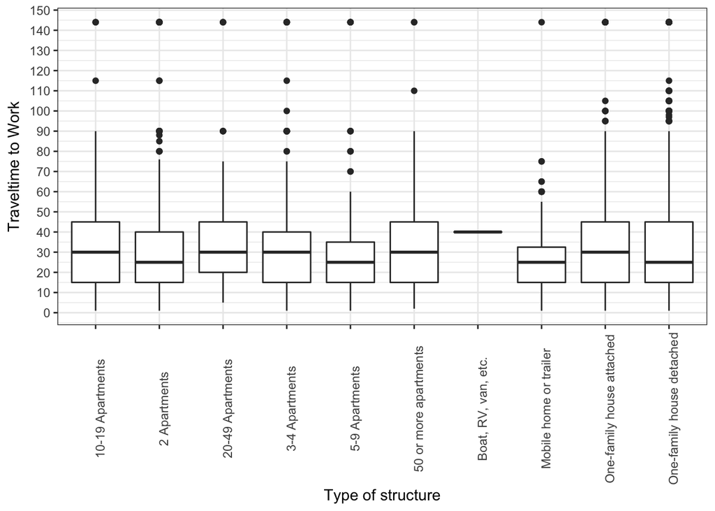

```r
ggplot(ma_re_trans_data, aes(x = BLD_label, y = JWMNP)) +
  geom_boxplot() +
  theme_bw() +
  theme(axis.text.x = element_text(angle = 90)) +
  scale_x_discrete(name = "Type of structure") +
  scale_y_continuous(name = "Traveltime to Work",
                     breaks = seq(0, 1000, by = 10),
                     labels = paste("",
                                    prettyNum(seq(0, 1000, by = 10),
                                              big.mark = ",")))
```

## Means of Transportation (Cat) and Traveltime (Con)

```r
anova <- aov(JWMNP ~ JWTR_label, data = ma_re_trans_data)

summary(anova)
```

```
##                Df   Sum Sq Mean Sq F value Pr(>F)
## JWTR_label     10  1341347  134135   249.7 <2e-16 ***
## Residuals   22991 12350846     537
## ---
## Signif. codes:  0 '***' 0.001 '**' 0.01 '*' 0.05 '.' 0.1 ' ' 1
```

```r
differences <- TukeyHSD(anova)

as_tibble(cbind(pair = row.names(differences$JWTR_label),
                differences$JWTR_label))
```

```
## # A tibble: 55 x 5
##    pair                           diff        lwr        upr        `p adj`
##    <chr>                          <chr>       <chr>      <chr>      <chr>
##  1 Bus or trolley bus-Bicycle     20.4307839… 13.174698… 27.686869… 0
##  2 Car, truck, or van-Bicycle     5.67166043… -0.462734… 11.806055… 0.100499088…
##  3 Ferryboat-Bicycle              37.2287801… 23.048641… 51.408918… 0
##  4 Motorcycle-Bicycle             2.19402074… -21.11682… 25.504866… 0.999999935…
##  5 Other method-Bicycle           15.6807169… 7.2367869… 24.124647… 0
##  6 Railroad-Bicycle               44.7258389… 37.848451… 51.603226… 0
##  7 Streetcar or trolley car (car… 17.7989158… 1.9417075… 33.656124… 0.013532470…
##  8 Subway or elevated-Bicycle     25.8556776… 19.159397… 32.551958… 0
##  9 Taxicab-Bicycle                -0.4574944… -15.38751… 14.472521… 0.999999999…
## 10 Walked-Bicycle                 -9.0577710… -16.05112… -2.064416… 0.001535002…
## # … with 45 more rows
```

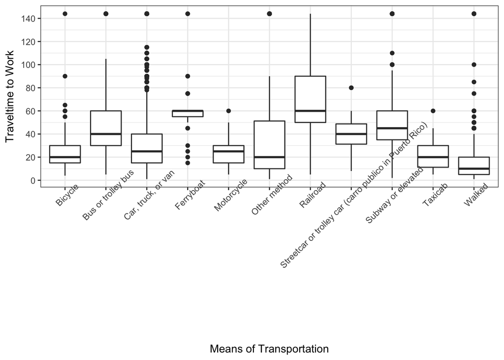

```r
ggplot(ma_re_trans_data, aes(x = JWTR_label, y = JWMNP)) +
  geom_boxplot() +
  theme_bw() +
  theme(axis.text.x = element_text(angle = 45)) +
  scale_x_discrete(name = "Means of Transportation") +
  scale_y_continuous(name = "Traveltime to Work",
                     breaks = seq(0, 1000, by = 20),
                     labels = paste("",
                                    prettyNum(seq(0, 1000, by = 20),
                                              big.mark = ",")))
```

# Relationship between two categorical variables - Chi-square test

## Type of Structure (Cat) and Transportation Type (Cat)

```r
chi_sq <- chisq.test(ma_re_trans_data$BLD_label, ma_re_trans_data$JWTR_label != "Car, truck, or van")
chi_sq
```

```
##
##  Pearson's Chi-squared test
##
## data:  ma_re_trans_data$BLD_label and ma_re_trans_data$JWTR_label != "Car, truck, or van"
## X-squared = 935.52, df = 9, p-value < 2.2e-16
```

```r
observation <- chi_sq
observation
```

```
##
##  Pearson's Chi-squared test
##
## data:  ma_re_trans_data$BLD_label and ma_re_trans_data$JWTR_label != "Car, truck, or van"
## X-squared = 935.52, df = 9, p-value < 2.2e-16
```

```r
expectation <- chi_sq
expectation
```

```
##
##  Pearson's Chi-squared test
##
## data:  ma_re_trans_data$BLD_label and ma_re_trans_data$JWTR_label != "Car, truck, or van"
## X-squared = 935.52, df = 9, p-value < 2.2e-16
```